# Introduction to R Packages

Lee Richardson  
11/17/2015

### Why make an R Package?

There are many good reasons for making an R package…

- Share code/data/documentation with other R users
- Organizing code, standardized tools, trustworthy software
- Allows others to utilize your new methods!
- Progression, having built something!

“It would be great if you could release this as an R Package!”

Jeremy Espino (2015)

“… from user to programmer to contributor, in the gradual progress that R encourages. Specifically: using R; simple programming; **packages** and methods; inter-system interfaces”

John Chambers

### What do we need? Devtools!

Devtools is the package created by Hadley Wickham, which automates common development tasks.

```r
  install.packages("devtools")
  library("devtools")
```

- This allows us to quickly create the required format's within R, without the hassles of the command line
- R itself provided the tools for packge management, devtools is just a convinient wrapper for implementation

### The 5 stages of an R package

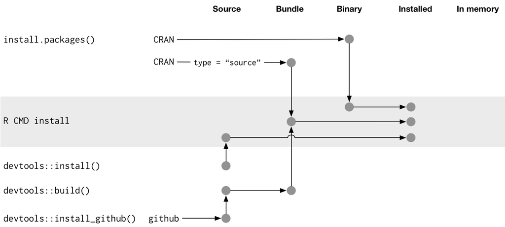

### Step 1: Initialize the repository

An R (*source*) package is just files in a directory, formatted in a specific way. To create the bare bones R package, just type:

```r
devtools::create("/home/lee/leeR")
```

This should give us:

1. Directory R/
2. NAMESPACE file
3. DESCRIPTION file
4. leeR.rproj file (if in R studio)

### Step 1: Here's what the package directory should look like

[figure not shown]

### Step 2: Write a function!

Now, create a file in the `R/` directory where we will put our first function. For example, we can create the file `R/examples.R` and add the function:

```r
leeR_demo <- function() {
  print("Hello World!")
}
```

### Step 3: Add Documentation

The easiest way to document your R functions is through the `roxygen2` package. This allows you to keep all of your documentation/code in a single file. To install:

```r
install.packages("roxygen2")
library(roxygen2)
```

At its core, R takes `.Rd` files location in a `man/` directory and renders them into either html, pdf, or whichever format is needed. But as you might guess…

### Step 3: Roxygen provides a format for documenting functing

We can add documentation to our function, for example:

```r
#' Print Hello World!
#'
#' @return A string saying "Hello World"
#' @examples
#' leeR_demo()
leeR_demo <- function() {
  print("Hello World!")
}
```

### Step 3: Devtools provides a wrapper for documentation!

As a standard workflow, we can use:

```r
devtools::document()
```

Now, this will create a `man/` folder, and insert the corresponding `man/leeR_demo.Rd` file that R uses to generate documentation. Finally, lets type:

```r
?leeR_demo
```

### Congratulations! You now have your own personal R Package

There are many more great features of to look into, including:

- Version Control (git/github)
- Automated Unit testing (testthat)
- Vignettes (long form documentation, knitr)

Many more details in the “R Packages” book by Hadley Wickham

### SPEW as an R Package!

[figure not shown]

### Bonus: Synchronizing the Package with Github

This allows users to install your package without being hosted on CRAN. For example, you could install the R package I just made using:

```r
devtools::install_github(username = "leerichardson", repo = "leeR")
library(leeR)
?leeR_demo
```

Amazingly, we've been able to write a pack for others to download within 30 minutes!

### Instructions for syncronizing with Github

1. Create a github repository with the same name as your package
2. Use the following commands from the command line:

```r
# echo "# packagename" >> README.md
# git init
# git add --all
# git commit -m "First Commit!"
# git remote add origin https://github.com/username/packagename.git
# git push -u origin master
```

### Now check out the Github page, all of the code is there!!!

Thanks!

Questions?